# Exercise 3

Jaymeee3

1. Import the dataset MoviesOnStreamingPlatforms.csv (note: the separator is a comma), which contains information about movies and TV series available on various streaming platforms (see metadata). Create a copy of the dataset and name it movies.

```r
mv <- read.csv("MoviesOnStreamingPlatforms.csv", sep = ",", header = TRUE)
```

2. Before working with the dataset, clean it. Rewrite the last two code chunks into a single one using the tidyverse programming paradigm (i.e., using mutate and pipelines), and run it. If you’re unable to do so, simply run the existing code.

```r
#to access pipeline construction and the mutate function
library("tidyverse")
names(mv) = str_to_lower(names(mv)) #Thanks to this operation, the variable names are now in lowercase.
names(mv)
```

```
##  [1] "x"               "id"              "title"           "year"
##  [5] "age"             "rotten.tomatoes" "netflix"         "hulu"
##  [9] "prime.video"     "disney."         "type"
```

```r
### rewrite the code starting from here: ###

# movies$rotten.tomatoes = movies$rotten.tomatoes = str_replace(movies$rotten.tomatoes, '/100', '')
# movies = movies %>% rename(review_score = rotten.tomatoes,
#                            prime_video = prime.video,
#                            disney_plus = disney.) %>%
#   select(-x)


mv <- mv %>% select(-x) %>% mutate(rotten.tomatoes=str_replace(mv$rotten.tomatoes,"/100", "")) %>%
                                     rename(review_score = rotten.tomatoes,
                                            prime_video = prime.video,
                                            disney_plus = disney.)

names(mv)
```

```
##  [1] "id"           "title"        "year"         "age"          "review_score"
##  [6] "netflix"      "hulu"         "prime_video"  "disney_plus"  "type"
```

3. Check whether the data types of the imported variables were correctly detected, and explain for which variables a type casting operation would be necessary.

```r
str(mv)
```

```
## 'data.frame':    9515 obs. of  10 variables:
##  $ id          : int  1 2 3 4 5 6 7 8 9 10 ...
##  $ title       : chr  "The Irishman" "Dangal" "David Attenborough: A Life on Our Planet" "Lagaan: Once Upon a Time in India" ...
##  $ year        : int  2019 2016 2020 2001 2018 2018 2020 2017 2018 2020 ...
##  $ age         : chr  "18+" "7+" "7+" "7+" ...
##  $ review_score: chr  "98" "97" "95" "94" ...
##  $ netflix     : int  1 1 1 1 1 1 1 1 1 1 ...
##  $ hulu        : int  0 0 0 0 0 0 0 0 0 0 ...
##  $ prime_video : int  0 0 0 0 0 0 0 0 0 0 ...
##  $ disney_plus : int  0 0 0 0 0 0 0 0 0 0 ...
##  $ type        : int  0 0 0 0 0 0 0 0 0 0 ...
```

```r
mv <- mv %>% mutate(id=as.numeric(id),
                    title=as.factor(title),
                    year=as.numeric(year),
                    age=as.factor(age),
                    review_score=as.factor(review_score),
                    netflix=as.numeric(netflix),
                    hulu=as.numeric(hulu),
                    prime_video=as.numeric(prime_video),
                    disney_plus=as.numeric(disney_plus),
                    type=as.numeric(type))

# the binary variables netflix, hulu, prime_video, disney_plus, and type are not numerical (cardinal) variables,
# but I convert them to interact with them more effectively; they cannot be converted to categorical (factor) variables
```

4. The variables netflix, hulu, prime_video, and disney_plus indicate whether a movie is available on the corresponding platform. Create a new variable platform_sum that counts how many platforms each movie is available on.

```r
mv <- mv %>% group_by(title) %>% mutate(platform_sum= sum(netflix, hulu, prime_video, disney_plus))
```

5. Graphically visualize the new variable platform_sum and provide comments.

```r
class(mv$platform_sum)
```

```
## [1] "numeric"
```

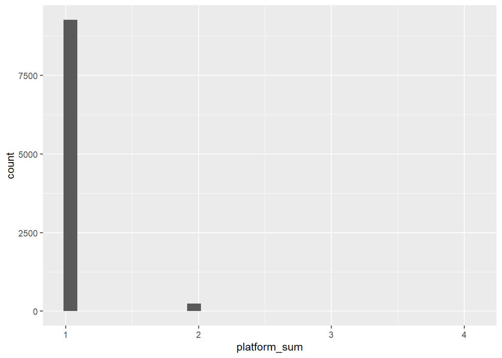

```r
mv %>% ggplot(aes(x=platform_sum)) + geom_histogram()
```

6. Extract the titles of the 8 movies available on the most platforms.

```r
mv %>% select(title, platform_sum) %>% arrange(desc(platform_sum))
```

```
## # A tibble: 9,515 × 2
## # Groups:   title [9,515]
##    title                        platform_sum
##    <fct>                               <dbl>
##  1 Zapped                                  4
##  2 Underworld                              3
##  3 Zack and Miri Make a Porno              3
##  4 The Outsider                            3
##  5 The Stepfather                          3
##  6 The Girl King                           3
##  7 A Second Chance                         3
##  8 For the Birds                           3
##  9 The Social Network                      2
## 10 Hey Arnold! The Jungle Movie            2
## # ℹ 9,505 more rows
```

7. Assume that the availability of a movie on Netflix (netflix) affects the review score (review_score, previously called rotten.tomatoes). Visualize the relationship between the variables and comment (hint: netflix can be treated as a categorical variable).

[figure not shown]

```r
# In this section, a bivariate graphical analysis will be conducted between two mixed variables. Therefore, the appropriate graphical representation is the boxplot. mv$netflix

mv %>% ggplot(aes(x = as.factor(netflix), y = review_score, fill = as.factor(netflix))) +
  geom_boxplot(notch = T, #notch on the median
               outlier.colour = "red" #color for the outliers
, alpha = 0.7) + #color transparency
  theme_minimal() +
  labs(x='Netflix', y='Review Score')
```

8. Try to replicate the visualization for movies rated 16+ and released before 2018 (age and year). Provide comments.

```r
names(mv)
```

```
##  [1] "id"           "title"        "year"         "age"          "review_score"
##  [6] "netflix"      "hulu"         "prime_video"  "disney_plus"  "type"
## [11] "platform_sum"
```

```r
unique(mv$year)
```

```
##   [1] 2019 2016 2020 2001 2018 2017 2004 2014 2015 2006 1991 2012 2010 2011 2013
##  [16] 2005 1998 2002 2009 1971 2003 2007 1975 1988 2008 1974 1979 1997 1990 2021
##  [31] 1984 2000 1993 1994 1999 1976 1964 1954 1982 1986 1992 1995 1987 1989 1980
##  [46] 1996 1958 1981 1977 1983 1970 1963 1985 1972 1962 1966 1956 1969 1973 1960
##  [61] 1959 1978 1968 1940 1941 1965 1923 1950 1953 1957 1955 1946 1936 1952 1967
##  [76] 1935 1951 1925 1947 1945 1948 1939 1942 1932 1937 1919 1949 1934 1931 1922
##  [91] 1927 1933 1920 1961 1944 1943 1915 1929 1938 1914 1930 1928 1916
```

[figure not shown]

```r
mv %>% filter(year<2018) %>%
  ggplot(aes(x = as.factor(netflix), y = review_score, fill = as.factor(netflix))) +
  geom_boxplot(notch = T, #notch on the median
               outlier.colour = "red" #color for the outliers
, alpha = 0.7) + #color transparency
  theme_minimal() +
  labs(x='Netflix', y='Review Score')
```